# Risk Factor Analysis

## Outcome Variable

**Outcome Variable:** ever_wasted

## Predictor Variables

**Intervention Variable:** parity

**Adjustment Set:**

- arm
- W_mage
- meducyrs
- feducyrs
- hhwealth_quart
- W_mhtcm
- W_mwtkg
- W_mbmi
- vagbrth
- W_nrooms
- impsan
- delta_W_mage
- delta_meducyrs
- delta_feducyrs
- delta_hhwealth_quart
- delta_W_mhtcm
- delta_W_mwtkg
- delta_W_mbmi
- delta_vagbrth
- delta_W_nrooms
- delta_impsan

## Stratifying Variables

The analysis was stratified on these variable(s):

- agecat
- studyid
- country

## Data Summary

| agecat | studyid | country | parity | ever_wasted | n_cell | n |
| --- | --- | --- | --- | --- | --- | --- |
| 0-24 months | COHORTS | GUATEMALA | 1 | 0 | 162 | 1341 |
| 0-24 months | COHORTS | GUATEMALA | 1 | 1 | 46 | 1341 |
| 0-24 months | COHORTS | GUATEMALA | 2 | 0 | 132 | 1341 |
| 0-24 months | COHORTS | GUATEMALA | 2 | 1 | 55 | 1341 |
| 0-24 months | COHORTS | GUATEMALA | 3+ | 0 | 705 | 1341 |
| 0-24 months | COHORTS | GUATEMALA | 3+ | 1 | 241 | 1341 |
| 0-24 months | COHORTS | INDIA | 1 | 0 | 560 | 4624 |
| 0-24 months | COHORTS | INDIA | 1 | 1 | 250 | 4624 |
| 0-24 months | COHORTS | INDIA | 2 | 0 | 821 | 4624 |
| 0-24 months | COHORTS | INDIA | 2 | 1 | 363 | 4624 |
| 0-24 months | COHORTS | INDIA | 3+ | 0 | 1681 | 4624 |
| 0-24 months | COHORTS | INDIA | 3+ | 1 | 949 | 4624 |
| 0-24 months | COHORTS | PHILIPPINES | 1 | 0 | 394 | 3045 |
| 0-24 months | COHORTS | PHILIPPINES | 1 | 1 | 283 | 3045 |
| 0-24 months | COHORTS | PHILIPPINES | 2 | 0 | 424 | 3045 |
| 0-24 months | COHORTS | PHILIPPINES | 2 | 1 | 258 | 3045 |
| 0-24 months | COHORTS | PHILIPPINES | 3+ | 0 | 998 | 3045 |
| 0-24 months | COHORTS | PHILIPPINES | 3+ | 1 | 688 | 3045 |
| 0-24 months | GMS-Nepal | NEPAL | 1 | 0 | 89 | 686 |
| 0-24 months | GMS-Nepal | NEPAL | 1 | 1 | 114 | 686 |
| 0-24 months | GMS-Nepal | NEPAL | 2 | 0 | 78 | 686 |
| 0-24 months | GMS-Nepal | NEPAL | 2 | 1 | 102 | 686 |
| 0-24 months | GMS-Nepal | NEPAL | 3+ | 0 | 114 | 686 |
| 0-24 months | GMS-Nepal | NEPAL | 3+ | 1 | 189 | 686 |
| 0-24 months | JiVitA-3 | BANGLADESH | 1 | 0 | 7422 | 26956 |
| 0-24 months | JiVitA-3 | BANGLADESH | 1 | 1 | 2704 | 26956 |
| 0-24 months | JiVitA-3 | BANGLADESH | 2 | 0 | 6779 | 26956 |
| 0-24 months | JiVitA-3 | BANGLADESH | 2 | 1 | 2155 | 26956 |
| 0-24 months | JiVitA-3 | BANGLADESH | 3+ | 0 | 5800 | 26956 |
| 0-24 months | JiVitA-3 | BANGLADESH | 3+ | 1 | 2096 | 26956 |

[output cut: 168 more lines]

The following strata were considered:

- agecat: 0-24 months, studyid: COHORTS, country: GUATEMALA
- agecat: 0-24 months, studyid: COHORTS, country: INDIA
- agecat: 0-24 months, studyid: COHORTS, country: PHILIPPINES
- agecat: 0-24 months, studyid: GMS-Nepal, country: NEPAL
- agecat: 0-24 months, studyid: JiVitA-3, country: BANGLADESH
- agecat: 0-24 months, studyid: Keneba, country: GAMBIA
- agecat: 0-24 months, studyid: PROVIDE, country: BANGLADESH
- agecat: 0-24 months, studyid: SAS-CompFeed, country: INDIA
- agecat: 0-24 months, studyid: SAS-FoodSuppl, country: INDIA
- agecat: 0-24 months, studyid: TanzaniaChild2, country: TANZANIA, UNITED REPUBLIC OF
- agecat: 0-24 months, studyid: ZVITAMBO, country: ZIMBABWE
- agecat: 0-6 months, studyid: COHORTS, country: GUATEMALA
- agecat: 0-6 months, studyid: COHORTS, country: INDIA
- agecat: 0-6 months, studyid: COHORTS, country: PHILIPPINES
- agecat: 0-6 months, studyid: GMS-Nepal, country: NEPAL
- agecat: 0-6 months, studyid: JiVitA-3, country: BANGLADESH
- agecat: 0-6 months, studyid: Keneba, country: GAMBIA
- agecat: 0-6 months, studyid: PROVIDE, country: BANGLADESH
- agecat: 0-6 months, studyid: SAS-CompFeed, country: INDIA
- agecat: 0-6 months, studyid: SAS-FoodSuppl, country: INDIA
- agecat: 0-6 months, studyid: TanzaniaChild2, country: TANZANIA, UNITED REPUBLIC OF
- agecat: 0-6 months, studyid: ZVITAMBO, country: ZIMBABWE
- agecat: 6-24 months, studyid: COHORTS, country: GUATEMALA
- agecat: 6-24 months, studyid: COHORTS, country: INDIA
- agecat: 6-24 months, studyid: COHORTS, country: PHILIPPINES
- agecat: 6-24 months, studyid: GMS-Nepal, country: NEPAL
- agecat: 6-24 months, studyid: JiVitA-3, country: BANGLADESH
- agecat: 6-24 months, studyid: Keneba, country: GAMBIA
- agecat: 6-24 months, studyid: PROVIDE, country: BANGLADESH
- agecat: 6-24 months, studyid: SAS-CompFeed, country: INDIA
- agecat: 6-24 months, studyid: SAS-FoodSuppl, country: INDIA
- agecat: 6-24 months, studyid: TanzaniaChild2, country: TANZANIA, UNITED REPUBLIC OF
- agecat: 6-24 months, studyid: ZVITAMBO, country: ZIMBABWE

### Dropped Strata

Some strata were dropped due to rare outcomes:

- agecat: 6-24 months, studyid: SAS-FoodSuppl, country: INDIA

## Methods Detail

We’re interested in the causal parameters $E[Y_a]$ for all values of $a \in \mathcal{A}$. These parameters represent the mean outcome if, possibly contrary to fact, we intervened to set all units to have $A=a$. Under the randomization and positivity assumptions, these are identified by the statistical parameters $\psi_a=E_W[E_{Y|A,W}(Y|A=a,W)]$. In addition, we’re interested in the mean of $Y$, $E[Y]$ under no intervention (the observed mean). We will estimate these parameters by using SuperLearner to fit the relevant likelihood factors – $E_{Y|A,W}(Y|A=a,W)$ and $p(A=a|W)$, and then updating our likelihood fit using a joint TMLE.

For unadjusted analyses ($W=\{\}$), initial likelihoods were estimated using Lrnr_glm to estimate the simple $E(Y|A)$ and Lrnr_mean to estimate $p(A)$. For adjusted analyses, a small library containing Lrnr_glmnet, Lrnr_xgboost, and Lrnr_mean was used.

Having estimated these parameters, we will then use the delta method to estimate relative risks and attributable risks relative to a prespecified baseline level of $A$.

# Results Detail

## Results Plots

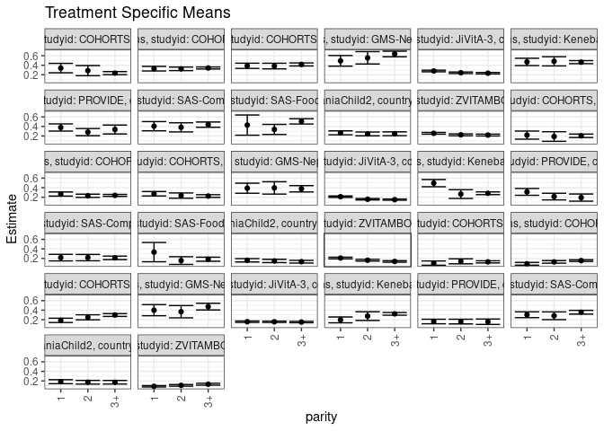

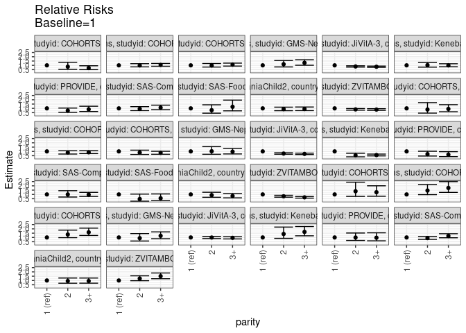

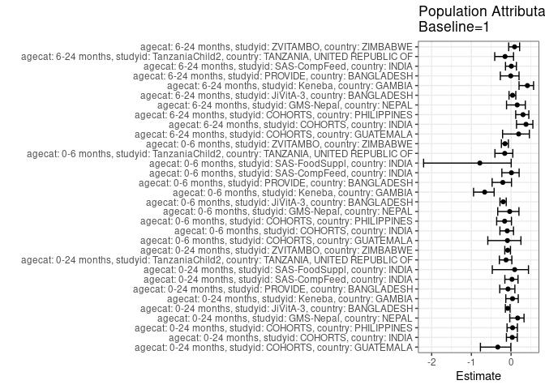

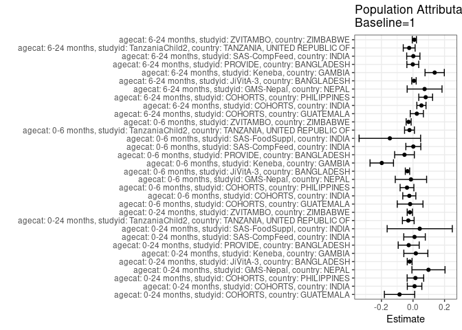

## Results Table

### Parameter: TSM

| agecat | studyid | country | intervention_level | baseline_level | estimate | ci_lower | ci_upper |
| --- | --- | --- | --- | --- | --- | --- | --- |
| 0-24 months | COHORTS | GUATEMALA | 1 | NA | 0.3402842 | 0.2415591 | 0.4390092 |
| 0-24 months | COHORTS | GUATEMALA | 2 | NA | 0.2868525 | 0.1804435 | 0.3932616 |
| 0-24 months | COHORTS | GUATEMALA | 3+ | NA | 0.2343865 | 0.2022621 | 0.2665109 |
| 0-24 months | COHORTS | INDIA | 1 | NA | 0.3277439 | 0.2798732 | 0.3756147 |
| 0-24 months | COHORTS | INDIA | 2 | NA | 0.3244185 | 0.2871178 | 0.3617191 |
| 0-24 months | COHORTS | INDIA | 3+ | NA | 0.3418457 | 0.3206803 | 0.3630110 |
| 0-24 months | COHORTS | PHILIPPINES | 1 | NA | 0.3882182 | 0.3332934 | 0.4431430 |
| 0-24 months | COHORTS | PHILIPPINES | 2 | NA | 0.3827506 | 0.3240907 | 0.4414105 |
| 0-24 months | COHORTS | PHILIPPINES | 3+ | NA | 0.4164264 | 0.3846100 | 0.4482428 |
| 0-24 months | GMS-Nepal | NEPAL | 1 | NA | 0.4922871 | 0.3807695 | 0.6038046 |
| 0-24 months | GMS-Nepal | NEPAL | 2 | NA | 0.5551531 | 0.4257395 | 0.6845667 |
| 0-24 months | GMS-Nepal | NEPAL | 3+ | NA | 0.6361977 | 0.5778752 | 0.6945202 |
| 0-24 months | JiVitA-3 | BANGLADESH | 1 | NA | 0.2793362 | 0.2627668 | 0.2959057 |
| 0-24 months | JiVitA-3 | BANGLADESH | 2 | NA | 0.2420887 | 0.2257929 | 0.2583845 |
| 0-24 months | JiVitA-3 | BANGLADESH | 3+ | NA | 0.2326747 | 0.2173814 | 0.2479679 |
| 0-24 months | Keneba | GAMBIA | 1 | NA | 0.4694314 | 0.3925204 | 0.5463424 |
| 0-24 months | Keneba | GAMBIA | 2 | NA | 0.4817270 | 0.3852341 | 0.5782199 |
| 0-24 months | Keneba | GAMBIA | 3+ | NA | 0.4648408 | 0.4329847 | 0.4966970 |
| 0-24 months | PROVIDE | BANGLADESH | 1 | NA | 0.3787174 | 0.3036469 | 0.4537879 |
| 0-24 months | PROVIDE | BANGLADESH | 2 | NA | 0.2811455 | 0.2061183 | 0.3561727 |
| 0-24 months | PROVIDE | BANGLADESH | 3+ | NA | 0.3361996 | 0.2427227 | 0.4296765 |
| 0-24 months | SAS-CompFeed | INDIA | 1 | NA | 0.4052898 | 0.3090166 | 0.5015631 |
| 0-24 months | SAS-CompFeed | INDIA | 2 | NA | 0.3810998 | 0.2855915 | 0.4766081 |
| 0-24 months | SAS-CompFeed | INDIA | 3+ | NA | 0.4381844 | 0.3829149 | 0.4934539 |
| 0-24 months | SAS-FoodSuppl | INDIA | 1 | NA | 0.4285714 | 0.2166616 | 0.6404813 |
| 0-24 months | SAS-FoodSuppl | INDIA | 2 | NA | 0.3376623 | 0.2319066 | 0.4434181 |
| 0-24 months | SAS-FoodSuppl | INDIA | 3+ | NA | 0.5062500 | 0.4514060 | 0.5610940 |
| 0-24 months | TanzaniaChild2 | TANZANIA, UNITED REPUBLIC OF | 1 | NA | 0.2666521 | 0.2254788 | 0.3078253 |
| 0-24 months | TanzaniaChild2 | TANZANIA, UNITED REPUBLIC OF | 2 | NA | 0.2435118 | 0.2038267 | 0.2831970 |
| 0-24 months | TanzaniaChild2 | TANZANIA, UNITED REPUBLIC OF | 3+ | NA | 0.2465759 | 0.2066401 | 0.2865118 |

[output cut: 66 more lines]

### Parameter: E(Y)

| agecat | studyid | country | intervention_level | baseline_level | estimate | ci_lower | ci_upper |
| --- | --- | --- | --- | --- | --- | --- | --- |
| 0-24 months | COHORTS | GUATEMALA | NA | NA | 0.2550336 | 0.2316956 | 0.2783715 |
| 0-24 months | COHORTS | INDIA | NA | NA | 0.3378028 | 0.3241691 | 0.3514364 |
| 0-24 months | COHORTS | PHILIPPINES | NA | NA | 0.4036125 | 0.3861835 | 0.4210415 |
| 0-24 months | GMS-Nepal | NEPAL | NA | NA | 0.5903790 | 0.5535526 | 0.6272054 |
| 0-24 months | JiVitA-3 | BANGLADESH | NA | NA | 0.2580131 | 0.2515484 | 0.2644777 |
| 0-24 months | Keneba | GAMBIA | NA | NA | 0.4874372 | 0.4654705 | 0.5094038 |
| 0-24 months | PROVIDE | BANGLADESH | NA | NA | 0.3514286 | 0.3160364 | 0.3868207 |
| 0-24 months | SAS-CompFeed | INDIA | NA | NA | 0.4150694 | 0.3581204 | 0.4720184 |
| 0-24 months | SAS-FoodSuppl | INDIA | NA | NA | 0.4712919 | 0.4233811 | 0.5192026 |
| 0-24 months | TanzaniaChild2 | TANZANIA, UNITED REPUBLIC OF | NA | NA | 0.2367416 | 0.2195770 | 0.2539062 |
| 0-24 months | ZVITAMBO | ZIMBABWE | NA | NA | 0.2367157 | 0.2296604 | 0.2437709 |
| 0-6 months | COHORTS | GUATEMALA | NA | NA | 0.2003763 | 0.1763021 | 0.2244505 |
| 0-6 months | COHORTS | INDIA | NA | NA | 0.2434743 | 0.2308547 | 0.2560940 |
| 0-6 months | COHORTS | PHILIPPINES | NA | NA | 0.2355453 | 0.2204685 | 0.2506222 |
| 0-6 months | GMS-Nepal | NEPAL | NA | NA | 0.3760933 | 0.3398180 | 0.4123685 |
| 0-6 months | JiVitA-3 | BANGLADESH | NA | NA | 0.1761793 | 0.1705546 | 0.1818041 |
| 0-6 months | Keneba | GAMBIA | NA | NA | 0.2976769 | 0.2768415 | 0.3185124 |
| 0-6 months | PROVIDE | BANGLADESH | NA | NA | 0.2585714 | 0.2261125 | 0.2910304 |
| 0-6 months | SAS-CompFeed | INDIA | NA | NA | 0.2199336 | 0.1753445 | 0.2645227 |
| 0-6 months | SAS-FoodSuppl | INDIA | NA | NA | 0.1866029 | 0.1492099 | 0.2239959 |
| 0-6 months | TanzaniaChild2 | TANZANIA, UNITED REPUBLIC OF | NA | NA | 0.1395842 | 0.1255905 | 0.1535779 |
| 0-6 months | ZVITAMBO | ZIMBABWE | NA | NA | 0.1811291 | 0.1747154 | 0.1875428 |
| 6-24 months | COHORTS | GUATEMALA | NA | NA | 0.1269580 | 0.1082147 | 0.1457012 |
| 6-24 months | COHORTS | INDIA | NA | NA | 0.1419682 | 0.1315821 | 0.1523542 |
| 6-24 months | COHORTS | PHILIPPINES | NA | NA | 0.2666429 | 0.2502871 | 0.2829988 |
| 6-24 months | GMS-Nepal | NEPAL | NA | NA | 0.4728814 | 0.4325613 | 0.5132014 |
| 6-24 months | JiVitA-3 | BANGLADESH | NA | NA | 0.1640074 | 0.1578946 | 0.1701202 |
| 6-24 months | Keneba | GAMBIA | NA | NA | 0.3336798 | 0.3126050 | 0.3547547 |
| 6-24 months | PROVIDE | BANGLADESH | NA | NA | 0.1609756 | 0.1319065 | 0.1900447 |
| 6-24 months | SAS-CompFeed | INDIA | NA | NA | 0.3059755 | 0.2638053 | 0.3481458 |
| 6-24 months | TanzaniaChild2 | TANZANIA, UNITED REPUBLIC OF | NA | NA | 0.1600403 | 0.1439152 | 0.1761654 |
| 6-24 months | ZVITAMBO | ZIMBABWE | NA | NA | 0.0958942 | 0.0903444 | 0.1014441 |

### Parameter: RR

| agecat | studyid | country | intervention_level | baseline_level | estimate | ci_lower | ci_upper |
| --- | --- | --- | --- | --- | --- | --- | --- |
| 0-24 months | COHORTS | GUATEMALA | 1 | 1 | 1.0000000 | 1.0000000 | 1.0000000 |
| 0-24 months | COHORTS | GUATEMALA | 2 | 1 | 0.8429794 | 0.5262830 | 1.3502511 |
| 0-24 months | COHORTS | GUATEMALA | 3+ | 1 | 0.6887964 | 0.4997719 | 0.9493140 |
| 0-24 months | COHORTS | INDIA | 1 | 1 | 1.0000000 | 1.0000000 | 1.0000000 |
| 0-24 months | COHORTS | INDIA | 2 | 1 | 0.9898534 | 0.8219916 | 1.1919949 |
| 0-24 months | COHORTS | INDIA | 3+ | 1 | 1.0430267 | 0.8901165 | 1.2222047 |
| 0-24 months | COHORTS | PHILIPPINES | 1 | 1 | 1.0000000 | 1.0000000 | 1.0000000 |
| 0-24 months | COHORTS | PHILIPPINES | 2 | 1 | 0.9859161 | 0.8003709 | 1.2144751 |
| 0-24 months | COHORTS | PHILIPPINES | 3+ | 1 | 1.0726608 | 0.9133380 | 1.2597758 |
| 0-24 months | GMS-Nepal | NEPAL | 1 | 1 | 1.0000000 | 1.0000000 | 1.0000000 |
| 0-24 months | GMS-Nepal | NEPAL | 2 | 1 | 1.1277020 | 0.8143979 | 1.5615360 |
| 0-24 months | GMS-Nepal | NEPAL | 3+ | 1 | 1.2923308 | 1.0121049 | 1.6501439 |
| 0-24 months | JiVitA-3 | BANGLADESH | 1 | 1 | 1.0000000 | 1.0000000 | 1.0000000 |
| 0-24 months | JiVitA-3 | BANGLADESH | 2 | 1 | 0.8666569 | 0.7959339 | 0.9436641 |
| 0-24 months | JiVitA-3 | BANGLADESH | 3+ | 1 | 0.8329555 | 0.7625799 | 0.9098257 |
| 0-24 months | Keneba | GAMBIA | 1 | 1 | 1.0000000 | 1.0000000 | 1.0000000 |
| 0-24 months | Keneba | GAMBIA | 2 | 1 | 1.0261926 | 0.7921951 | 1.3293080 |
| 0-24 months | Keneba | GAMBIA | 3+ | 1 | 0.9902210 | 0.8291350 | 1.1826032 |
| 0-24 months | PROVIDE | BANGLADESH | 1 | 1 | 1.0000000 | 1.0000000 | 1.0000000 |
| 0-24 months | PROVIDE | BANGLADESH | 2 | 1 | 0.7423623 | 0.5330469 | 1.0338709 |
| 0-24 months | PROVIDE | BANGLADESH | 3+ | 1 | 0.8877321 | 0.6315647 | 1.2478030 |
| 0-24 months | SAS-CompFeed | INDIA | 1 | 1 | 1.0000000 | 1.0000000 | 1.0000000 |
| 0-24 months | SAS-CompFeed | INDIA | 2 | 1 | 0.9403143 | 0.7378563 | 1.1983241 |
| 0-24 months | SAS-CompFeed | INDIA | 3+ | 1 | 1.0811629 | 0.8516036 | 1.3726025 |
| 0-24 months | SAS-FoodSuppl | INDIA | 1 | 1 | 1.0000000 | 1.0000000 | 1.0000000 |
| 0-24 months | SAS-FoodSuppl | INDIA | 2 | 1 | 0.7878788 | 0.4387984 | 1.4146657 |
| 0-24 months | SAS-FoodSuppl | INDIA | 3+ | 1 | 1.1812500 | 0.7120467 | 1.9596350 |
| 0-24 months | TanzaniaChild2 | TANZANIA, UNITED REPUBLIC OF | 1 | 1 | 1.0000000 | 1.0000000 | 1.0000000 |
| 0-24 months | TanzaniaChild2 | TANZANIA, UNITED REPUBLIC OF | 2 | 1 | 0.9132194 | 0.7297474 | 1.1428196 |
| 0-24 months | TanzaniaChild2 | TANZANIA, UNITED REPUBLIC OF | 3+ | 1 | 0.9247104 | 0.7391661 | 1.1568297 |

[output cut: 66 more lines]

### Parameter: PAR

| agecat | studyid | country | intervention_level | baseline_level | estimate | ci_lower | ci_upper |
| --- | --- | --- | --- | --- | --- | --- | --- |
| 0-24 months | COHORTS | GUATEMALA | 1 | NA | -0.0852506 | -0.1813594 | 0.0108582 |
| 0-24 months | COHORTS | INDIA | 1 | NA | 0.0100588 | -0.0360124 | 0.0561301 |
| 0-24 months | COHORTS | PHILIPPINES | 1 | NA | 0.0153943 | -0.0370853 | 0.0678738 |
| 0-24 months | GMS-Nepal | NEPAL | 1 | NA | 0.0980919 | -0.0069398 | 0.2031237 |
| 0-24 months | JiVitA-3 | BANGLADESH | 1 | NA | -0.0213232 | -0.0365517 | -0.0060947 |
| 0-24 months | Keneba | GAMBIA | 1 | NA | 0.0180058 | -0.0581310 | 0.0941426 |
| 0-24 months | PROVIDE | BANGLADESH | 1 | NA | -0.0272888 | -0.0938155 | 0.0392379 |
| 0-24 months | SAS-CompFeed | INDIA | 1 | NA | 0.0097795 | -0.0584239 | 0.0779830 |
| 0-24 months | SAS-FoodSuppl | INDIA | 1 | NA | 0.0427204 | -0.1638931 | 0.2493340 |
| 0-24 months | TanzaniaChild2 | TANZANIA, UNITED REPUBLIC OF | 1 | NA | -0.0299105 | -0.0670243 | 0.0072034 |
| 0-24 months | ZVITAMBO | ZIMBABWE | 1 | NA | -0.0199454 | -0.0367647 | -0.0031261 |
| 0-6 months | COHORTS | GUATEMALA | 1 | NA | -0.0182700 | -0.0998821 | 0.0633420 |
| 0-6 months | COHORTS | INDIA | 1 | NA | -0.0234175 | -0.0648734 | 0.0180384 |
| 0-6 months | COHORTS | PHILIPPINES | 1 | NA | -0.0379953 | -0.0816601 | 0.0056696 |
| 0-6 months | GMS-Nepal | NEPAL | 1 | NA | -0.0130364 | -0.1124119 | 0.0863392 |
| 0-6 months | JiVitA-3 | BANGLADESH | 1 | NA | -0.0349159 | -0.0487356 | -0.0210961 |
| 0-6 months | Keneba | GAMBIA | 1 | NA | -0.1980316 | -0.2724406 | -0.1236227 |
| 0-6 months | PROVIDE | BANGLADESH | 1 | NA | -0.0538871 | -0.1164282 | 0.0086540 |
| 0-6 months | SAS-CompFeed | INDIA | 1 | NA | 0.0020762 | -0.0452771 | 0.0494294 |
| 0-6 months | SAS-FoodSuppl | INDIA | 1 | NA | -0.1467305 | -0.3417992 | 0.0483382 |
| 0-6 months | TanzaniaChild2 | TANZANIA, UNITED REPUBLIC OF | 1 | NA | -0.0222472 | -0.0535066 | 0.0090123 |
| 0-6 months | ZVITAMBO | ZIMBABWE | 1 | NA | -0.0275643 | -0.0434755 | -0.0116532 |
| 6-24 months | COHORTS | GUATEMALA | 1 | NA | 0.0242699 | -0.0174653 | 0.0660051 |
| 6-24 months | COHORTS | INDIA | 1 | NA | 0.0534629 | 0.0244612 | 0.0824647 |
| 6-24 months | COHORTS | PHILIPPINES | 1 | NA | 0.0804259 | 0.0366017 | 0.1242500 |
| 6-24 months | GMS-Nepal | NEPAL | 1 | NA | 0.0734893 | -0.0370191 | 0.1839977 |
| 6-24 months | JiVitA-3 | BANGLADESH | 1 | NA | 0.0062091 | -0.0078068 | 0.0202250 |
| 6-24 months | Keneba | GAMBIA | 1 | NA | 0.1374605 | 0.0763191 | 0.1986018 |
| 6-24 months | PROVIDE | BANGLADESH | 1 | NA | -0.0012477 | -0.0388487 | 0.0363533 |
| 6-24 months | SAS-CompFeed | INDIA | 1 | NA | 0.0020304 | -0.0398719 | 0.0439327 |
| 6-24 months | TanzaniaChild2 | TANZANIA, UNITED REPUBLIC OF | 1 | NA | -0.0241071 | -0.0617242 | 0.0135099 |
| 6-24 months | ZVITAMBO | ZIMBABWE | 1 | NA | 0.0084899 | -0.0046736 | 0.0216533 |

### Parameter: PAF

| agecat | studyid | country | intervention_level | baseline_level | estimate | ci_lower | ci_upper |
| --- | --- | --- | --- | --- | --- | --- | --- |
| 0-24 months | COHORTS | GUATEMALA | 1 | NA | -0.3342721 | -0.7716822 | -0.0048540 |
| 0-24 months | COHORTS | INDIA | 1 | NA | 0.0297773 | -0.1166467 | 0.1570009 |
| 0-24 months | COHORTS | PHILIPPINES | 1 | NA | 0.0381413 | -0.1010511 | 0.1597372 |
| 0-24 months | GMS-Nepal | NEPAL | 1 | NA | 0.1661508 | -0.0326117 | 0.3266544 |
| 0-24 months | JiVitA-3 | BANGLADESH | 1 | NA | -0.0826438 | -0.1433335 | -0.0251757 |
| 0-24 months | Keneba | GAMBIA | 1 | NA | 0.0369397 | -0.1324361 | 0.1809824 |
| 0-24 months | PROVIDE | BANGLADESH | 1 | NA | -0.0776511 | -0.2848765 | 0.0961530 |
| 0-24 months | SAS-CompFeed | INDIA | 1 | NA | 0.0235612 | -0.1561051 | 0.1753063 |
| 0-24 months | SAS-FoodSuppl | INDIA | 1 | NA | 0.0906454 | -0.4727690 | 0.4385231 |
| 0-24 months | TanzaniaChild2 | TANZANIA, UNITED REPUBLIC OF | 1 | NA | -0.1263422 | -0.2946618 | 0.0200941 |
| 0-24 months | ZVITAMBO | ZIMBABWE | 1 | NA | -0.0842590 | -0.1577395 | -0.0154422 |
| 0-6 months | COHORTS | GUATEMALA | 1 | NA | -0.0911786 | -0.5855725 | 0.2490594 |
| 0-6 months | COHORTS | INDIA | 1 | NA | -0.0961807 | -0.2804532 | 0.0615728 |
| 0-6 months | COHORTS | PHILIPPINES | 1 | NA | -0.1613077 | -0.3625044 | 0.0101790 |
| 0-6 months | GMS-Nepal | NEPAL | 1 | NA | -0.0346626 | -0.3357535 | 0.1985597 |
| 0-6 months | JiVitA-3 | BANGLADESH | 1 | NA | -0.1981837 | -0.2795160 | -0.1220212 |
| 0-6 months | Keneba | GAMBIA | 1 | NA | -0.6652569 | -0.9445156 | -0.4261035 |
| 0-6 months | PROVIDE | BANGLADESH | 1 | NA | -0.2084030 | -0.4767403 | 0.0111749 |
| 0-6 months | SAS-CompFeed | INDIA | 1 | NA | 0.0094400 | -0.2313389 | 0.2031364 |
| 0-6 months | SAS-FoodSuppl | INDIA | 1 | NA | -0.7863248 | -2.2032501 | 0.0038379 |
| 0-6 months | TanzaniaChild2 | TANZANIA, UNITED REPUBLIC OF | 1 | NA | -0.1593816 | -0.4062987 | 0.0441819 |
| 0-6 months | ZVITAMBO | ZIMBABWE | 1 | NA | -0.1521807 | -0.2434889 | -0.0675771 |
| 6-24 months | COHORTS | GUATEMALA | 1 | NA | 0.1911648 | -0.2132994 | 0.4607973 |
| 6-24 months | COHORTS | INDIA | 1 | NA | 0.3765839 | 0.1374260 | 0.5494327 |
| 6-24 months | COHORTS | PHILIPPINES | 1 | NA | 0.3016238 | 0.1171659 | 0.4475414 |
| 6-24 months | GMS-Nepal | NEPAL | 1 | NA | 0.1554075 | -0.1138202 | 0.3595586 |
| 6-24 months | JiVitA-3 | BANGLADESH | 1 | NA | 0.0378587 | -0.0514779 | 0.1196051 |
| 6-24 months | Keneba | GAMBIA | 1 | NA | 0.4119533 | 0.2009464 | 0.5672393 |
| 6-24 months | PROVIDE | BANGLADESH | 1 | NA | -0.0077510 | -0.2706202 | 0.2007352 |
| 6-24 months | SAS-CompFeed | INDIA | 1 | NA | 0.0066358 | -0.1402526 | 0.1346020 |
| 6-24 months | TanzaniaChild2 | TANZANIA, UNITED REPUBLIC OF | 1 | NA | -0.1506318 | -0.4113424 | 0.0619190 |
| 6-24 months | ZVITAMBO | ZIMBABWE | 1 | NA | 0.0885339 | -0.0594516 | 0.2158486 |